# Lab 4

## Dan Shao, Yingjie Gao

### 03/14/2019

## Exercise #1 - 3 points

The following link contains a table of information about the moons in our solar system:

https://en.wikipedia.org/wiki/List_of_natural_satellites (Links to an external site.)

Using techniques that we have covered over the previous several classes, import the table directly from the above URL into a DataFrame, and then process the data into a clean form that is ready for analysis. For this part, you are expected to identify and correct as many issues as possible, and properly validate/demonstrate that the issues are fully corrected. Please provide a summary of the identified and corrected issues in your notebook (e.g., as a bulleted list up front, or one-by-one as you complete each task), and also output a .csv file of your tidy data that you will upload as part of your submission. You will be evaluated on the quality of your final DataFrame, as well as the quality of your approach in processing the data.

```python
import pandas as pd
```

```python
solar_system = pd.read_html('https://en.wikipedia.org/wiki/List_of_natural_satellites', match='Image')[0]
solar_system
```

|  | Image | Numeral | Name | Mean radius (km) | Semi-major axis (km) | Sidereal period (d) (r = retrograde) | Discovery year | Discovered by | Notes | Ref(s) | Planet |
| --- | --- | --- | --- | --- | --- | --- | --- | --- | --- | --- | --- |
| 0 | NaN | I | Moon | 1737.10 | 384399 | 27.321582 | Prehistoric | — | Synchronous rotation | [13] | Earth |
| 1 | NaN | I | Phobos | 11.1 ± 0.15 | 9380 | 0.319 | 1877 | Hall | NaN | [14][15][16] | Mars |
| 2 | NaN | II | Deimos | 6.2 ± 0.18 | 23460 | 1.262 | 1877 | Hall | NaN | [14][15][16] | Mars |
| 3 | NaN | I | Io | 1818.1 ± 0.1 | 421800 | 1.769 | 1610 | Galileo | Main-group moon (Galilean) | [16][17] | Jupiter |
| 4 | NaN | II | Europa | 1560.7 ± 0.7 | 671100 | 3.551 | 1610 | Galileo | Main-group moon (Galilean) | [16][17] | Jupiter |
| 5 | NaN | III | Ganymede | 2634.1 ± 0.3 | 1070400 | 7.155 | 1610 | Galileo | Main-group moon (Galilean) | [16][17] | Jupiter |
| 6 | NaN | IV | Callisto | 2408.4 ± 0.3 | 1882700 | 16.69 | 1610 | Galileo | Main-group moon (Galilean) | [16][17] | Jupiter |
| 7 | NaN | V | Amalthea | 83.45 ± 2.4 | 181400 | 0.498 | 1892 | Barnard | Inner moon (Amalthea) | [15][16][18] | Jupiter |
| 8 | NaN | VI | Himalia | 67 ± 10[19] | 11461000 | 250.56 | 1904 | Perrine | Prograde irregular (Himalia) | [15][16][20] | Jupiter |
| 9 | NaN | VII | Elara | 43 | 11741000 | 259.64 | 1905 | Perrine | Prograde irregular (Himalia) | [15][16][21] | Jupiter |
| 10 | NaN | VIII | Pasiphae | 30 | 23624000 | 743.63 (r) | 1908 | Melotte | Retrograde irregular (Pasiphae) | [15][16][22] | Jupiter |
| 11 | NaN | IX | Sinope | 19 | 23939000 | 758.90 (r) | 1914 | Nicholson | Retrograde irregular (Pasiphae) | [15][16][23] | Jupiter |
| 12 | NaN | X | Lysithea | 18 | 11717000 | 259.20 | 1938 | Nicholson | Prograde irregular (Himalia) | [15][16][24] | Jupiter |
| 13 | NaN | XI | Carme | 23 | 23404000 | 734.17 (r) | 1938 | Nicholson | Retrograde irregular (Carme) | [15][16][24] | Jupiter |
| 14 | NaN | XII | Ananke | 14 | 21276000 | 629.77 (r) | 1951 | Nicholson | Retrograde irregular (Ananke) | [15][16][25] | Jupiter |
| 15 | NaN | XIII | Leda | 10 | 11165000 | 240.92 | 1974 | Kowal | Prograde irregular (Himalia) | [15][16][26] | Jupiter |
| 16 | NaN | XIV | Thebe | 49.3 ± 2.0 | 221900 | 0.675 | 1979 | Synnott (Voyager 1) | Inner moon (Amalthea) | [15][16][27] | Jupiter |
| 17 | NaN | XV | Adrastea | 8.2 ± 2.0 | 129000 | 0.298 | 1979 | Jewitt, Danielson (Voyager 1) | Inner moon (Amalthea) | [15][16][28] | Jupiter |
| 18 | NaN | XVI | Metis | 21.5 ± 2.0 | 128000 | 0.295 | 1979 | Synnott (Voyager 1) | Inner moon (Amalthea) | [15][16][29] | Jupiter |
| 19 | NaN | XVII | Callirrhoe | 4.3 | 24103000 | 758.77 (r) | 2000 | Scotti, Spahr, McMillan, Larsen, Montani, Glea... | Retrograde irregular (Pasiphae) | [15][16][30] | Jupiter |
| 20 | NaN | XVIII | Themisto | 4.0 | 7284000 | 130.02 | 1975/2000 | Kowal and Roemer (original); Sheppard, Jewitt,... | Prograde irregular (Themisto) | [15][16][31][32] | Jupiter |
| 21 | NaN | XIX | Megaclite | 2.7 | 23493000 | 752.86 (r) | 2000 | Sheppard, Jewitt, Fernández, Magnier, Dahm, Evans | Retrograde irregular (Pasiphae) | [15][16][33] | Jupiter |
| 22 | NaN | XX | Taygete | 2.5 | 23280000 | 732.41 (r) | 2000 | Sheppard, Jewitt, Fernández, Magnier, Dahm, Evans | Retrograde irregular (Carme) | [15][16][33] | Jupiter |
| 23 | NaN | XXI | Chaldene | 1.9 | 23100000 | 723.72 (r) | 2000 | Sheppard, Jewitt, Fernández, Magnier, Dahm, Evans | Retrograde irregular (Carme) | [15][16][33] | Jupiter |
| 24 | NaN | XXII | Harpalyke | 2.2 | 20858000 | 623.32 (r) | 2000 | Sheppard, Jewitt, Fernández, Magnier, Dahm, Evans | Retrograde irregular (Ananke) | [15][16][33] | Jupiter |
| 25 | NaN | XXIII | Kalyke | 2.6 | 23483000 | 742.06 (r) | 2000 | Sheppard, Jewitt, Fernández, Magnier, Dahm, Evans | Retrograde irregular (Carme) | [15][16][33] | Jupiter |
| 26 | NaN | XXIV | Iocaste | 2.6 | 21060000 | 631.60 (r) | 2000 | Sheppard, Jewitt, Fernández, Magnier, Dahm, Evans | Retrograde irregular (Ananke) | [15][16][33] | Jupiter |
| 27 | NaN | XXV | Erinome | 1.6 | 23196000 | 728.46 (r) | 2000 | Sheppard, Jewitt, Fernández, Magnier, Dahm, Evans | Retrograde irregular (Carme) | [15][16][33] | Jupiter |
| 28 | NaN | XXVI | Isonoe | 1.9 | 23155000 | 726.23 (r) | 2000 | Sheppard, Jewitt, Fernández, Magnier, Dahm, Evans | Retrograde irregular (Carme) | [15][16][33] | Jupiter |
| 29 | NaN | XXVII | Praxidike | 3.4 | 20908000 | 625.39 (r) | 2000 | Sheppard, Jewitt, Fernández, Magnier, Dahm, Evans | Retrograde irregular (Ananke) | [15][16][33] | Jupiter |
| ... | ... | ... | ... | ... | ... | ... | ... | ... | ... | ... | ... |
| 164 | NaN | XXI | Trinculo | 5 | 8504000 | 749.24 (r) | 2001 | Holman, Kavelaars, Milisavljevic | Retrograde irregular | [15][16] | Uranus |
| 165 | NaN | XXII | Francisco | 6 | 4276000 | 266.56 (r) | 2001 | Holman, Kavelaars, Milisavljevic, Gladman | Retrograde irregular | [15][16] | Uranus |
| 166 | NaN | XXIII | Margaret | 5.5 | 14345000 | 1687.01 | 2003 | Sheppard, Jewitt | Prograde irregular | [15][16] | Uranus |
| 167 | NaN | XXIV | Ferdinand | 6 | 20901000 | 2,887.21 (r) | 2001 | Holman, Kavelaars, Milisavljevic, et al. | Retrograde irregular | [15][16] | Uranus |
| 168 | NaN | XXV | Perdita | 10 | 76417 | 0.638 | 1986 | Karkoschka (Voyager 2) | Inner moon | [16] | Uranus |
| 169 | NaN | XXVI | Mab | 5 | 97736 | 0.923 | 2003 | Showalter, Lissauer | Inner moon | [16] | Uranus |
| 170 | NaN | XXVII | Cupid | 5 | 74392 | 0.613 | 2003 | Showalter, Lissauer | Inner moon | [16] | Uranus |
| 171 | NaN | I | Triton | 1353.4 ± 0.9 | 354800 | 5.877 (r) | 1846 | Lassell | Retrograde irregular | [15][16] | Neptune |
| 172 | NaN | II | Nereid | 170 ± 25 | 5513820 | 360.14 | 1949 | Kuiper | Prograde irregular | [15][16] | Neptune |
| 173 | NaN | III | Naiad | 33 ± 3 | 48224 | 0.294 | 1989 | Terrile (Voyager 2) | Inner moon | [15][16] | Neptune |
| 174 | NaN | IV | Thalassa | 41 ± 3 | 50075 | 0.311 | 1989 | Terrile (Voyager 2) | Inner moon | [15][16] | Neptune |
| 175 | NaN | V | Despina | 75 ± 3 | 52526 | 0.335 | 1989 | Synnott (Voyager 2) | Inner moon | [15][16] | Neptune |
| 176 | NaN | VI | Galatea | 88 ± 4 | 61953 | 0.429 | 1989 | Synnott (Voyager 2) | Inner moon | [15][16] | Neptune |
| 177 | NaN | VII | Larissa | 97 ± 3 | 73548 | 0.555 | 1982 | Reitsema, Hubbard, Lebofsky, Tholen (Voyager 2) | Inner moon | [15][16] | Neptune |
| 178 | NaN | VIII | Proteus | 210 ± 7 | 117647 | 1.122 | 1989 | Synnott (Voyager 2) | Inner moon | [15][16] | Neptune |
| 179 | NaN | IX | Halimede | 31 | 15728000 | 1,879.71 (r) | 2002 | Holman, Kavelaars, Grav, Fraser, Milisavljevic | Retrograde irregular | [15][16] | Neptune |
| 180 | NaN | X | Psamathe | 20 | 46695000 | 9,115.91 (r) | 2003 | Jewitt, Kleyna, Sheppard, Holman, Kavelaars | Retrograde irregular | [15][16] | Neptune |
| 181 | NaN | XI | Sao | 22 | 22422000 | 2914.07 | 2002 | Holman, Kavelaars, Grav, Fraser, Milisavljevic | Prograde irregular | [15][16] | Neptune |
| 182 | NaN | XII | Laomedeia | 21 | 23571000 | 3167.85 | 2002 | Holman, Kavelaars, Grav, Fraser, Milisavljevic | Prograde irregular | [15][16] | Neptune |
| 183 | NaN | XIII | Neso | 30 | 48387000 | 9,373.99 (r) | 2002 | Holman, Kavelaars, Grav, Fraser, Milisavljevic | Retrograde irregular | [15][16] | Neptune |
| 184 | NaN | XIV | Hippocamp | 17.4 | 105283 | 0.9362 | 2013 | Showalter et al. | Inner moon | [39] | Neptune |
| 185 | NaN | I | Charon | 603.6 ± 1.4 | 19591 | 6.387 | 1978 | Christy | NaN | [15][16] | Pluto |
| 186 | NaN | II | Nix | 23.0 ± 2 | 48671 | 24.85 | 2005 | Weaver, Stern, Buie, et al. | NaN | [15][16] | Pluto |
| 187 | NaN | III | Hydra | 30.5 ± 4 | 64698 | 38.20 | 2005 | Weaver, Stern, Buie, et al. | NaN | [15][16] | Pluto |
| 188 | NaN | IV | Kerberos | 14.0 | 57729 | 32.17 | 2011 | Showalter (Hubble) | NaN | [15][16][40][41] | Pluto |
| 189 | NaN | V | Styx | 10.0 | 42393 | 20.16 | 2012 | Showalter (Hubble) | NaN | [15][16][42] | Pluto |
| 190 | NaN | I | Hiʻiaka | ~160 | 49,500 ± 400 | 49.12 ± 0.03 | 2005 | Brown et al. | NaN | [7][43] | Haumea |
| 191 | NaN | II | Namaka | ~85 | 39,000 (r) | 34.7 ± 0.1if e = 0 | 2005 | Brown et al. | NaN | [7][43] | Haumea |
| 192 | NaN | — | S/2015 (136472) 1 | ~80 | NaN | NaN | 2016 | Parker et al. | NaN | [44] | Makemake |
| 193 | NaN | I | Dysnomia | 257± 110[9] | 37,370 ± 150 | 15.774 ± 0.002 | 2005 | Brown, Rabinowitz, Trujillo et al. | SDO moon | [45][46][47] | Eris |

194 rows × 11 columns

- Drop Image and Ref(s)

```python
solar_system.drop(['Image','Ref(s)'], axis=1, inplace=True)
solar_system
```

|  | Numeral | Name | Mean radius (km) | Semi-major axis (km) | Sidereal period (d) (r = retrograde) | Discovery year | Discovered by | Notes | Planet |
| --- | --- | --- | --- | --- | --- | --- | --- | --- | --- |
| 0 | I | Moon | 1737.10 | 384399 | 27.321582 | Prehistoric | — | Synchronous rotation | Earth |
| 1 | I | Phobos | 11.1 ± 0.15 | 9380 | 0.319 | 1877 | Hall | NaN | Mars |
| 2 | II | Deimos | 6.2 ± 0.18 | 23460 | 1.262 | 1877 | Hall | NaN | Mars |
| 3 | I | Io | 1818.1 ± 0.1 | 421800 | 1.769 | 1610 | Galileo | Main-group moon (Galilean) | Jupiter |
| 4 | II | Europa | 1560.7 ± 0.7 | 671100 | 3.551 | 1610 | Galileo | Main-group moon (Galilean) | Jupiter |
| 5 | III | Ganymede | 2634.1 ± 0.3 | 1070400 | 7.155 | 1610 | Galileo | Main-group moon (Galilean) | Jupiter |
| 6 | IV | Callisto | 2408.4 ± 0.3 | 1882700 | 16.69 | 1610 | Galileo | Main-group moon (Galilean) | Jupiter |
| 7 | V | Amalthea | 83.45 ± 2.4 | 181400 | 0.498 | 1892 | Barnard | Inner moon (Amalthea) | Jupiter |
| 8 | VI | Himalia | 67 ± 10[19] | 11461000 | 250.56 | 1904 | Perrine | Prograde irregular (Himalia) | Jupiter |
| 9 | VII | Elara | 43 | 11741000 | 259.64 | 1905 | Perrine | Prograde irregular (Himalia) | Jupiter |
| 10 | VIII | Pasiphae | 30 | 23624000 | 743.63 (r) | 1908 | Melotte | Retrograde irregular (Pasiphae) | Jupiter |
| 11 | IX | Sinope | 19 | 23939000 | 758.90 (r) | 1914 | Nicholson | Retrograde irregular (Pasiphae) | Jupiter |
| 12 | X | Lysithea | 18 | 11717000 | 259.20 | 1938 | Nicholson | Prograde irregular (Himalia) | Jupiter |
| 13 | XI | Carme | 23 | 23404000 | 734.17 (r) | 1938 | Nicholson | Retrograde irregular (Carme) | Jupiter |
| 14 | XII | Ananke | 14 | 21276000 | 629.77 (r) | 1951 | Nicholson | Retrograde irregular (Ananke) | Jupiter |
| 15 | XIII | Leda | 10 | 11165000 | 240.92 | 1974 | Kowal | Prograde irregular (Himalia) | Jupiter |
| 16 | XIV | Thebe | 49.3 ± 2.0 | 221900 | 0.675 | 1979 | Synnott (Voyager 1) | Inner moon (Amalthea) | Jupiter |
| 17 | XV | Adrastea | 8.2 ± 2.0 | 129000 | 0.298 | 1979 | Jewitt, Danielson (Voyager 1) | Inner moon (Amalthea) | Jupiter |
| 18 | XVI | Metis | 21.5 ± 2.0 | 128000 | 0.295 | 1979 | Synnott (Voyager 1) | Inner moon (Amalthea) | Jupiter |
| 19 | XVII | Callirrhoe | 4.3 | 24103000 | 758.77 (r) | 2000 | Scotti, Spahr, McMillan, Larsen, Montani, Glea... | Retrograde irregular (Pasiphae) | Jupiter |
| 20 | XVIII | Themisto | 4.0 | 7284000 | 130.02 | 1975/2000 | Kowal and Roemer (original); Sheppard, Jewitt,... | Prograde irregular (Themisto) | Jupiter |
| 21 | XIX | Megaclite | 2.7 | 23493000 | 752.86 (r) | 2000 | Sheppard, Jewitt, Fernández, Magnier, Dahm, Evans | Retrograde irregular (Pasiphae) | Jupiter |
| 22 | XX | Taygete | 2.5 | 23280000 | 732.41 (r) | 2000 | Sheppard, Jewitt, Fernández, Magnier, Dahm, Evans | Retrograde irregular (Carme) | Jupiter |
| 23 | XXI | Chaldene | 1.9 | 23100000 | 723.72 (r) | 2000 | Sheppard, Jewitt, Fernández, Magnier, Dahm, Evans | Retrograde irregular (Carme) | Jupiter |
| 24 | XXII | Harpalyke | 2.2 | 20858000 | 623.32 (r) | 2000 | Sheppard, Jewitt, Fernández, Magnier, Dahm, Evans | Retrograde irregular (Ananke) | Jupiter |
| 25 | XXIII | Kalyke | 2.6 | 23483000 | 742.06 (r) | 2000 | Sheppard, Jewitt, Fernández, Magnier, Dahm, Evans | Retrograde irregular (Carme) | Jupiter |
| 26 | XXIV | Iocaste | 2.6 | 21060000 | 631.60 (r) | 2000 | Sheppard, Jewitt, Fernández, Magnier, Dahm, Evans | Retrograde irregular (Ananke) | Jupiter |
| 27 | XXV | Erinome | 1.6 | 23196000 | 728.46 (r) | 2000 | Sheppard, Jewitt, Fernández, Magnier, Dahm, Evans | Retrograde irregular (Carme) | Jupiter |
| 28 | XXVI | Isonoe | 1.9 | 23155000 | 726.23 (r) | 2000 | Sheppard, Jewitt, Fernández, Magnier, Dahm, Evans | Retrograde irregular (Carme) | Jupiter |
| 29 | XXVII | Praxidike | 3.4 | 20908000 | 625.39 (r) | 2000 | Sheppard, Jewitt, Fernández, Magnier, Dahm, Evans | Retrograde irregular (Ananke) | Jupiter |
| ... | ... | ... | ... | ... | ... | ... | ... | ... | ... |
| 164 | XXI | Trinculo | 5 | 8504000 | 749.24 (r) | 2001 | Holman, Kavelaars, Milisavljevic | Retrograde irregular | Uranus |
| 165 | XXII | Francisco | 6 | 4276000 | 266.56 (r) | 2001 | Holman, Kavelaars, Milisavljevic, Gladman | Retrograde irregular | Uranus |
| 166 | XXIII | Margaret | 5.5 | 14345000 | 1687.01 | 2003 | Sheppard, Jewitt | Prograde irregular | Uranus |
| 167 | XXIV | Ferdinand | 6 | 20901000 | 2,887.21 (r) | 2001 | Holman, Kavelaars, Milisavljevic, et al. | Retrograde irregular | Uranus |
| 168 | XXV | Perdita | 10 | 76417 | 0.638 | 1986 | Karkoschka (Voyager 2) | Inner moon | Uranus |
| 169 | XXVI | Mab | 5 | 97736 | 0.923 | 2003 | Showalter, Lissauer | Inner moon | Uranus |
| 170 | XXVII | Cupid | 5 | 74392 | 0.613 | 2003 | Showalter, Lissauer | Inner moon | Uranus |
| 171 | I | Triton | 1353.4 ± 0.9 | 354800 | 5.877 (r) | 1846 | Lassell | Retrograde irregular | Neptune |
| 172 | II | Nereid | 170 ± 25 | 5513820 | 360.14 | 1949 | Kuiper | Prograde irregular | Neptune |
| 173 | III | Naiad | 33 ± 3 | 48224 | 0.294 | 1989 | Terrile (Voyager 2) | Inner moon | Neptune |
| 174 | IV | Thalassa | 41 ± 3 | 50075 | 0.311 | 1989 | Terrile (Voyager 2) | Inner moon | Neptune |
| 175 | V | Despina | 75 ± 3 | 52526 | 0.335 | 1989 | Synnott (Voyager 2) | Inner moon | Neptune |
| 176 | VI | Galatea | 88 ± 4 | 61953 | 0.429 | 1989 | Synnott (Voyager 2) | Inner moon | Neptune |
| 177 | VII | Larissa | 97 ± 3 | 73548 | 0.555 | 1982 | Reitsema, Hubbard, Lebofsky, Tholen (Voyager 2) | Inner moon | Neptune |
| 178 | VIII | Proteus | 210 ± 7 | 117647 | 1.122 | 1989 | Synnott (Voyager 2) | Inner moon | Neptune |
| 179 | IX | Halimede | 31 | 15728000 | 1,879.71 (r) | 2002 | Holman, Kavelaars, Grav, Fraser, Milisavljevic | Retrograde irregular | Neptune |
| 180 | X | Psamathe | 20 | 46695000 | 9,115.91 (r) | 2003 | Jewitt, Kleyna, Sheppard, Holman, Kavelaars | Retrograde irregular | Neptune |
| 181 | XI | Sao | 22 | 22422000 | 2914.07 | 2002 | Holman, Kavelaars, Grav, Fraser, Milisavljevic | Prograde irregular | Neptune |
| 182 | XII | Laomedeia | 21 | 23571000 | 3167.85 | 2002 | Holman, Kavelaars, Grav, Fraser, Milisavljevic | Prograde irregular | Neptune |
| 183 | XIII | Neso | 30 | 48387000 | 9,373.99 (r) | 2002 | Holman, Kavelaars, Grav, Fraser, Milisavljevic | Retrograde irregular | Neptune |
| 184 | XIV | Hippocamp | 17.4 | 105283 | 0.9362 | 2013 | Showalter et al. | Inner moon | Neptune |
| 185 | I | Charon | 603.6 ± 1.4 | 19591 | 6.387 | 1978 | Christy | NaN | Pluto |
| 186 | II | Nix | 23.0 ± 2 | 48671 | 24.85 | 2005 | Weaver, Stern, Buie, et al. | NaN | Pluto |
| 187 | III | Hydra | 30.5 ± 4 | 64698 | 38.20 | 2005 | Weaver, Stern, Buie, et al. | NaN | Pluto |
| 188 | IV | Kerberos | 14.0 | 57729 | 32.17 | 2011 | Showalter (Hubble) | NaN | Pluto |
| 189 | V | Styx | 10.0 | 42393 | 20.16 | 2012 | Showalter (Hubble) | NaN | Pluto |
| 190 | I | Hiʻiaka | ~160 | 49,500 ± 400 | 49.12 ± 0.03 | 2005 | Brown et al. | NaN | Haumea |
| 191 | II | Namaka | ~85 | 39,000 (r) | 34.7 ± 0.1if e = 0 | 2005 | Brown et al. | NaN | Haumea |
| 192 | — | S/2015 (136472) 1 | ~80 | NaN | NaN | 2016 | Parker et al. | NaN | Makemake |
| 193 | I | Dysnomia | 257± 110[9] | 37,370 ± 150 | 15.774 ± 0.002 | 2005 | Brown, Rabinowitz, Trujillo et al. | SDO moon | Eris |

194 rows × 9 columns

- Reorder the columns

```python
solar_system = solar_system[['Planet','Discovery year','Name','Numeral','Discovered by','Mean radius (km)','Semi-major axis (km)','Sidereal period (d) (r = retrograde)','Notes']]
solar_system
```

|  | Planet | Discovery year | Name | Numeral | Discovered by | Mean radius (km) | Semi-major axis (km) | Sidereal period (d) (r = retrograde) | Notes |
| --- | --- | --- | --- | --- | --- | --- | --- | --- | --- |
| 0 | Earth | Prehistoric | Moon | I | — | 1737.10 | 384399 | 27.321582 | Synchronous rotation |
| 1 | Mars | 1877 | Phobos | I | Hall | 11.1 ± 0.15 | 9380 | 0.319 | NaN |
| 2 | Mars | 1877 | Deimos | II | Hall | 6.2 ± 0.18 | 23460 | 1.262 | NaN |
| 3 | Jupiter | 1610 | Io | I | Galileo | 1818.1 ± 0.1 | 421800 | 1.769 | Main-group moon (Galilean) |
| 4 | Jupiter | 1610 | Europa | II | Galileo | 1560.7 ± 0.7 | 671100 | 3.551 | Main-group moon (Galilean) |
| 5 | Jupiter | 1610 | Ganymede | III | Galileo | 2634.1 ± 0.3 | 1070400 | 7.155 | Main-group moon (Galilean) |
| 6 | Jupiter | 1610 | Callisto | IV | Galileo | 2408.4 ± 0.3 | 1882700 | 16.69 | Main-group moon (Galilean) |
| 7 | Jupiter | 1892 | Amalthea | V | Barnard | 83.45 ± 2.4 | 181400 | 0.498 | Inner moon (Amalthea) |
| 8 | Jupiter | 1904 | Himalia | VI | Perrine | 67 ± 10[19] | 11461000 | 250.56 | Prograde irregular (Himalia) |
| 9 | Jupiter | 1905 | Elara | VII | Perrine | 43 | 11741000 | 259.64 | Prograde irregular (Himalia) |
| 10 | Jupiter | 1908 | Pasiphae | VIII | Melotte | 30 | 23624000 | 743.63 (r) | Retrograde irregular (Pasiphae) |
| 11 | Jupiter | 1914 | Sinope | IX | Nicholson | 19 | 23939000 | 758.90 (r) | Retrograde irregular (Pasiphae) |
| 12 | Jupiter | 1938 | Lysithea | X | Nicholson | 18 | 11717000 | 259.20 | Prograde irregular (Himalia) |
| 13 | Jupiter | 1938 | Carme | XI | Nicholson | 23 | 23404000 | 734.17 (r) | Retrograde irregular (Carme) |
| 14 | Jupiter | 1951 | Ananke | XII | Nicholson | 14 | 21276000 | 629.77 (r) | Retrograde irregular (Ananke) |
| 15 | Jupiter | 1974 | Leda | XIII | Kowal | 10 | 11165000 | 240.92 | Prograde irregular (Himalia) |
| 16 | Jupiter | 1979 | Thebe | XIV | Synnott (Voyager 1) | 49.3 ± 2.0 | 221900 | 0.675 | Inner moon (Amalthea) |
| 17 | Jupiter | 1979 | Adrastea | XV | Jewitt, Danielson (Voyager 1) | 8.2 ± 2.0 | 129000 | 0.298 | Inner moon (Amalthea) |
| 18 | Jupiter | 1979 | Metis | XVI | Synnott (Voyager 1) | 21.5 ± 2.0 | 128000 | 0.295 | Inner moon (Amalthea) |
| 19 | Jupiter | 2000 | Callirrhoe | XVII | Scotti, Spahr, McMillan, Larsen, Montani, Glea... | 4.3 | 24103000 | 758.77 (r) | Retrograde irregular (Pasiphae) |
| 20 | Jupiter | 1975/2000 | Themisto | XVIII | Kowal and Roemer (original); Sheppard, Jewitt,... | 4.0 | 7284000 | 130.02 | Prograde irregular (Themisto) |
| 21 | Jupiter | 2000 | Megaclite | XIX | Sheppard, Jewitt, Fernández, Magnier, Dahm, Evans | 2.7 | 23493000 | 752.86 (r) | Retrograde irregular (Pasiphae) |
| 22 | Jupiter | 2000 | Taygete | XX | Sheppard, Jewitt, Fernández, Magnier, Dahm, Evans | 2.5 | 23280000 | 732.41 (r) | Retrograde irregular (Carme) |
| 23 | Jupiter | 2000 | Chaldene | XXI | Sheppard, Jewitt, Fernández, Magnier, Dahm, Evans | 1.9 | 23100000 | 723.72 (r) | Retrograde irregular (Carme) |
| 24 | Jupiter | 2000 | Harpalyke | XXII | Sheppard, Jewitt, Fernández, Magnier, Dahm, Evans | 2.2 | 20858000 | 623.32 (r) | Retrograde irregular (Ananke) |
| 25 | Jupiter | 2000 | Kalyke | XXIII | Sheppard, Jewitt, Fernández, Magnier, Dahm, Evans | 2.6 | 23483000 | 742.06 (r) | Retrograde irregular (Carme) |
| 26 | Jupiter | 2000 | Iocaste | XXIV | Sheppard, Jewitt, Fernández, Magnier, Dahm, Evans | 2.6 | 21060000 | 631.60 (r) | Retrograde irregular (Ananke) |
| 27 | Jupiter | 2000 | Erinome | XXV | Sheppard, Jewitt, Fernández, Magnier, Dahm, Evans | 1.6 | 23196000 | 728.46 (r) | Retrograde irregular (Carme) |
| 28 | Jupiter | 2000 | Isonoe | XXVI | Sheppard, Jewitt, Fernández, Magnier, Dahm, Evans | 1.9 | 23155000 | 726.23 (r) | Retrograde irregular (Carme) |
| 29 | Jupiter | 2000 | Praxidike | XXVII | Sheppard, Jewitt, Fernández, Magnier, Dahm, Evans | 3.4 | 20908000 | 625.39 (r) | Retrograde irregular (Ananke) |
| ... | ... | ... | ... | ... | ... | ... | ... | ... | ... |
| 164 | Uranus | 2001 | Trinculo | XXI | Holman, Kavelaars, Milisavljevic | 5 | 8504000 | 749.24 (r) | Retrograde irregular |
| 165 | Uranus | 2001 | Francisco | XXII | Holman, Kavelaars, Milisavljevic, Gladman | 6 | 4276000 | 266.56 (r) | Retrograde irregular |
| 166 | Uranus | 2003 | Margaret | XXIII | Sheppard, Jewitt | 5.5 | 14345000 | 1687.01 | Prograde irregular |
| 167 | Uranus | 2001 | Ferdinand | XXIV | Holman, Kavelaars, Milisavljevic, et al. | 6 | 20901000 | 2,887.21 (r) | Retrograde irregular |
| 168 | Uranus | 1986 | Perdita | XXV | Karkoschka (Voyager 2) | 10 | 76417 | 0.638 | Inner moon |
| 169 | Uranus | 2003 | Mab | XXVI | Showalter, Lissauer | 5 | 97736 | 0.923 | Inner moon |
| 170 | Uranus | 2003 | Cupid | XXVII | Showalter, Lissauer | 5 | 74392 | 0.613 | Inner moon |
| 171 | Neptune | 1846 | Triton | I | Lassell | 1353.4 ± 0.9 | 354800 | 5.877 (r) | Retrograde irregular |
| 172 | Neptune | 1949 | Nereid | II | Kuiper | 170 ± 25 | 5513820 | 360.14 | Prograde irregular |
| 173 | Neptune | 1989 | Naiad | III | Terrile (Voyager 2) | 33 ± 3 | 48224 | 0.294 | Inner moon |
| 174 | Neptune | 1989 | Thalassa | IV | Terrile (Voyager 2) | 41 ± 3 | 50075 | 0.311 | Inner moon |
| 175 | Neptune | 1989 | Despina | V | Synnott (Voyager 2) | 75 ± 3 | 52526 | 0.335 | Inner moon |
| 176 | Neptune | 1989 | Galatea | VI | Synnott (Voyager 2) | 88 ± 4 | 61953 | 0.429 | Inner moon |
| 177 | Neptune | 1982 | Larissa | VII | Reitsema, Hubbard, Lebofsky, Tholen (Voyager 2) | 97 ± 3 | 73548 | 0.555 | Inner moon |
| 178 | Neptune | 1989 | Proteus | VIII | Synnott (Voyager 2) | 210 ± 7 | 117647 | 1.122 | Inner moon |
| 179 | Neptune | 2002 | Halimede | IX | Holman, Kavelaars, Grav, Fraser, Milisavljevic | 31 | 15728000 | 1,879.71 (r) | Retrograde irregular |
| 180 | Neptune | 2003 | Psamathe | X | Jewitt, Kleyna, Sheppard, Holman, Kavelaars | 20 | 46695000 | 9,115.91 (r) | Retrograde irregular |
| 181 | Neptune | 2002 | Sao | XI | Holman, Kavelaars, Grav, Fraser, Milisavljevic | 22 | 22422000 | 2914.07 | Prograde irregular |
| 182 | Neptune | 2002 | Laomedeia | XII | Holman, Kavelaars, Grav, Fraser, Milisavljevic | 21 | 23571000 | 3167.85 | Prograde irregular |
| 183 | Neptune | 2002 | Neso | XIII | Holman, Kavelaars, Grav, Fraser, Milisavljevic | 30 | 48387000 | 9,373.99 (r) | Retrograde irregular |
| 184 | Neptune | 2013 | Hippocamp | XIV | Showalter et al. | 17.4 | 105283 | 0.9362 | Inner moon |
| 185 | Pluto | 1978 | Charon | I | Christy | 603.6 ± 1.4 | 19591 | 6.387 | NaN |
| 186 | Pluto | 2005 | Nix | II | Weaver, Stern, Buie, et al. | 23.0 ± 2 | 48671 | 24.85 | NaN |
| 187 | Pluto | 2005 | Hydra | III | Weaver, Stern, Buie, et al. | 30.5 ± 4 | 64698 | 38.20 | NaN |
| 188 | Pluto | 2011 | Kerberos | IV | Showalter (Hubble) | 14.0 | 57729 | 32.17 | NaN |
| 189 | Pluto | 2012 | Styx | V | Showalter (Hubble) | 10.0 | 42393 | 20.16 | NaN |
| 190 | Haumea | 2005 | Hiʻiaka | I | Brown et al. | ~160 | 49,500 ± 400 | 49.12 ± 0.03 | NaN |
| 191 | Haumea | 2005 | Namaka | II | Brown et al. | ~85 | 39,000 (r) | 34.7 ± 0.1if e = 0 | NaN |
| 192 | Makemake | 2016 | S/2015 (136472) 1 | — | Parker et al. | ~80 | NaN | NaN | NaN |
| 193 | Eris | 2005 | Dysnomia | I | Brown, Rabinowitz, Trujillo et al. | 257± 110[9] | 37,370 ± 150 | 15.774 ± 0.002 | SDO moon |

194 rows × 9 columns

- Replace all "—" to NaN

```python
import numpy as np
```

```python
solar_system.replace({'—': np.nan}, inplace=True)
solar_system
```

|  | Planet | Discovery year | Name | Numeral | Discovered by | Mean radius (km) | Semi-major axis (km) | Sidereal period (d) (r = retrograde) | Notes |
| --- | --- | --- | --- | --- | --- | --- | --- | --- | --- |
| 0 | Earth | Prehistoric | Moon | I | NaN | 1737.10 | 384399 | 27.321582 | Synchronous rotation |
| 1 | Mars | 1877 | Phobos | I | Hall | 11.1 ± 0.15 | 9380 | 0.319 | NaN |
| 2 | Mars | 1877 | Deimos | II | Hall | 6.2 ± 0.18 | 23460 | 1.262 | NaN |
| 3 | Jupiter | 1610 | Io | I | Galileo | 1818.1 ± 0.1 | 421800 | 1.769 | Main-group moon (Galilean) |
| 4 | Jupiter | 1610 | Europa | II | Galileo | 1560.7 ± 0.7 | 671100 | 3.551 | Main-group moon (Galilean) |
| 5 | Jupiter | 1610 | Ganymede | III | Galileo | 2634.1 ± 0.3 | 1070400 | 7.155 | Main-group moon (Galilean) |
| 6 | Jupiter | 1610 | Callisto | IV | Galileo | 2408.4 ± 0.3 | 1882700 | 16.69 | Main-group moon (Galilean) |
| 7 | Jupiter | 1892 | Amalthea | V | Barnard | 83.45 ± 2.4 | 181400 | 0.498 | Inner moon (Amalthea) |
| 8 | Jupiter | 1904 | Himalia | VI | Perrine | 67 ± 10[19] | 11461000 | 250.56 | Prograde irregular (Himalia) |
| 9 | Jupiter | 1905 | Elara | VII | Perrine | 43 | 11741000 | 259.64 | Prograde irregular (Himalia) |
| 10 | Jupiter | 1908 | Pasiphae | VIII | Melotte | 30 | 23624000 | 743.63 (r) | Retrograde irregular (Pasiphae) |
| 11 | Jupiter | 1914 | Sinope | IX | Nicholson | 19 | 23939000 | 758.90 (r) | Retrograde irregular (Pasiphae) |
| 12 | Jupiter | 1938 | Lysithea | X | Nicholson | 18 | 11717000 | 259.20 | Prograde irregular (Himalia) |
| 13 | Jupiter | 1938 | Carme | XI | Nicholson | 23 | 23404000 | 734.17 (r) | Retrograde irregular (Carme) |
| 14 | Jupiter | 1951 | Ananke | XII | Nicholson | 14 | 21276000 | 629.77 (r) | Retrograde irregular (Ananke) |
| 15 | Jupiter | 1974 | Leda | XIII | Kowal | 10 | 11165000 | 240.92 | Prograde irregular (Himalia) |
| 16 | Jupiter | 1979 | Thebe | XIV | Synnott (Voyager 1) | 49.3 ± 2.0 | 221900 | 0.675 | Inner moon (Amalthea) |
| 17 | Jupiter | 1979 | Adrastea | XV | Jewitt, Danielson (Voyager 1) | 8.2 ± 2.0 | 129000 | 0.298 | Inner moon (Amalthea) |
| 18 | Jupiter | 1979 | Metis | XVI | Synnott (Voyager 1) | 21.5 ± 2.0 | 128000 | 0.295 | Inner moon (Amalthea) |
| 19 | Jupiter | 2000 | Callirrhoe | XVII | Scotti, Spahr, McMillan, Larsen, Montani, Glea... | 4.3 | 24103000 | 758.77 (r) | Retrograde irregular (Pasiphae) |
| 20 | Jupiter | 1975/2000 | Themisto | XVIII | Kowal and Roemer (original); Sheppard, Jewitt,... | 4.0 | 7284000 | 130.02 | Prograde irregular (Themisto) |
| 21 | Jupiter | 2000 | Megaclite | XIX | Sheppard, Jewitt, Fernández, Magnier, Dahm, Evans | 2.7 | 23493000 | 752.86 (r) | Retrograde irregular (Pasiphae) |
| 22 | Jupiter | 2000 | Taygete | XX | Sheppard, Jewitt, Fernández, Magnier, Dahm, Evans | 2.5 | 23280000 | 732.41 (r) | Retrograde irregular (Carme) |
| 23 | Jupiter | 2000 | Chaldene | XXI | Sheppard, Jewitt, Fernández, Magnier, Dahm, Evans | 1.9 | 23100000 | 723.72 (r) | Retrograde irregular (Carme) |
| 24 | Jupiter | 2000 | Harpalyke | XXII | Sheppard, Jewitt, Fernández, Magnier, Dahm, Evans | 2.2 | 20858000 | 623.32 (r) | Retrograde irregular (Ananke) |
| 25 | Jupiter | 2000 | Kalyke | XXIII | Sheppard, Jewitt, Fernández, Magnier, Dahm, Evans | 2.6 | 23483000 | 742.06 (r) | Retrograde irregular (Carme) |
| 26 | Jupiter | 2000 | Iocaste | XXIV | Sheppard, Jewitt, Fernández, Magnier, Dahm, Evans | 2.6 | 21060000 | 631.60 (r) | Retrograde irregular (Ananke) |
| 27 | Jupiter | 2000 | Erinome | XXV | Sheppard, Jewitt, Fernández, Magnier, Dahm, Evans | 1.6 | 23196000 | 728.46 (r) | Retrograde irregular (Carme) |
| 28 | Jupiter | 2000 | Isonoe | XXVI | Sheppard, Jewitt, Fernández, Magnier, Dahm, Evans | 1.9 | 23155000 | 726.23 (r) | Retrograde irregular (Carme) |
| 29 | Jupiter | 2000 | Praxidike | XXVII | Sheppard, Jewitt, Fernández, Magnier, Dahm, Evans | 3.4 | 20908000 | 625.39 (r) | Retrograde irregular (Ananke) |
| ... | ... | ... | ... | ... | ... | ... | ... | ... | ... |
| 164 | Uranus | 2001 | Trinculo | XXI | Holman, Kavelaars, Milisavljevic | 5 | 8504000 | 749.24 (r) | Retrograde irregular |
| 165 | Uranus | 2001 | Francisco | XXII | Holman, Kavelaars, Milisavljevic, Gladman | 6 | 4276000 | 266.56 (r) | Retrograde irregular |
| 166 | Uranus | 2003 | Margaret | XXIII | Sheppard, Jewitt | 5.5 | 14345000 | 1687.01 | Prograde irregular |
| 167 | Uranus | 2001 | Ferdinand | XXIV | Holman, Kavelaars, Milisavljevic, et al. | 6 | 20901000 | 2,887.21 (r) | Retrograde irregular |
| 168 | Uranus | 1986 | Perdita | XXV | Karkoschka (Voyager 2) | 10 | 76417 | 0.638 | Inner moon |
| 169 | Uranus | 2003 | Mab | XXVI | Showalter, Lissauer | 5 | 97736 | 0.923 | Inner moon |
| 170 | Uranus | 2003 | Cupid | XXVII | Showalter, Lissauer | 5 | 74392 | 0.613 | Inner moon |
| 171 | Neptune | 1846 | Triton | I | Lassell | 1353.4 ± 0.9 | 354800 | 5.877 (r) | Retrograde irregular |
| 172 | Neptune | 1949 | Nereid | II | Kuiper | 170 ± 25 | 5513820 | 360.14 | Prograde irregular |
| 173 | Neptune | 1989 | Naiad | III | Terrile (Voyager 2) | 33 ± 3 | 48224 | 0.294 | Inner moon |
| 174 | Neptune | 1989 | Thalassa | IV | Terrile (Voyager 2) | 41 ± 3 | 50075 | 0.311 | Inner moon |
| 175 | Neptune | 1989 | Despina | V | Synnott (Voyager 2) | 75 ± 3 | 52526 | 0.335 | Inner moon |
| 176 | Neptune | 1989 | Galatea | VI | Synnott (Voyager 2) | 88 ± 4 | 61953 | 0.429 | Inner moon |
| 177 | Neptune | 1982 | Larissa | VII | Reitsema, Hubbard, Lebofsky, Tholen (Voyager 2) | 97 ± 3 | 73548 | 0.555 | Inner moon |
| 178 | Neptune | 1989 | Proteus | VIII | Synnott (Voyager 2) | 210 ± 7 | 117647 | 1.122 | Inner moon |
| 179 | Neptune | 2002 | Halimede | IX | Holman, Kavelaars, Grav, Fraser, Milisavljevic | 31 | 15728000 | 1,879.71 (r) | Retrograde irregular |
| 180 | Neptune | 2003 | Psamathe | X | Jewitt, Kleyna, Sheppard, Holman, Kavelaars | 20 | 46695000 | 9,115.91 (r) | Retrograde irregular |
| 181 | Neptune | 2002 | Sao | XI | Holman, Kavelaars, Grav, Fraser, Milisavljevic | 22 | 22422000 | 2914.07 | Prograde irregular |
| 182 | Neptune | 2002 | Laomedeia | XII | Holman, Kavelaars, Grav, Fraser, Milisavljevic | 21 | 23571000 | 3167.85 | Prograde irregular |
| 183 | Neptune | 2002 | Neso | XIII | Holman, Kavelaars, Grav, Fraser, Milisavljevic | 30 | 48387000 | 9,373.99 (r) | Retrograde irregular |
| 184 | Neptune | 2013 | Hippocamp | XIV | Showalter et al. | 17.4 | 105283 | 0.9362 | Inner moon |
| 185 | Pluto | 1978 | Charon | I | Christy | 603.6 ± 1.4 | 19591 | 6.387 | NaN |
| 186 | Pluto | 2005 | Nix | II | Weaver, Stern, Buie, et al. | 23.0 ± 2 | 48671 | 24.85 | NaN |
| 187 | Pluto | 2005 | Hydra | III | Weaver, Stern, Buie, et al. | 30.5 ± 4 | 64698 | 38.20 | NaN |
| 188 | Pluto | 2011 | Kerberos | IV | Showalter (Hubble) | 14.0 | 57729 | 32.17 | NaN |
| 189 | Pluto | 2012 | Styx | V | Showalter (Hubble) | 10.0 | 42393 | 20.16 | NaN |
| 190 | Haumea | 2005 | Hiʻiaka | I | Brown et al. | ~160 | 49,500 ± 400 | 49.12 ± 0.03 | NaN |
| 191 | Haumea | 2005 | Namaka | II | Brown et al. | ~85 | 39,000 (r) | 34.7 ± 0.1if e = 0 | NaN |
| 192 | Makemake | 2016 | S/2015 (136472) 1 | NaN | Parker et al. | ~80 | NaN | NaN | NaN |
| 193 | Eris | 2005 | Dysnomia | I | Brown, Rabinowitz, Trujillo et al. | 257± 110[9] | 37,370 ± 150 | 15.774 ± 0.002 | SDO moon |

194 rows × 9 columns

```python
solar_system['Mean radius (km)'] = solar_system['Mean radius (km)'].str.split(expand=True)
solar_system['Semi-major axis (km)'] = solar_system['Semi-major axis (km)'].str.split(expand=True)
solar_system['Mean radius (km)'] = solar_system['Mean radius (km)'].str.split("–", expand=True)
solar_system['Mean radius (km)'] = solar_system['Mean radius (km)'].str.replace('±','')
solar_system['Mean radius (km)'] = solar_system['Mean radius (km)'].str.replace('~','')
solar_system['Semi-major axis (km)'] = solar_system['Semi-major axis (km)'].str.replace(',','')
solar_system['Mean radius (km)'] = solar_system['Mean radius (km)'].astype('float', copy=False)
solar_system['Semi-major axis (km)'] = solar_system['Semi-major axis (km)'].astype('float', copy=False)
```

- Hierarchical indexing (Planet, Discovery year)

```python
solar_system = solar_system.set_index(keys=['Planet','Discovery year']).sort_index(level=(0,1))
```

## Exercise #2 - 1 point

Given the tidy data that you processed in Exercise #1, formulate an interesting question about this data. Then, perform the appropriate analysis needed to address the question and describe your results. You will be evaluated on both the quality of your question and the quality of your analysis and description.

```python
solar_system
```

| Planet | Discovery year | Name | Numeral | Discovered by | Mean radius (km) | Semi-major axis (km) | Sidereal period (d) (r = retrograde) | Notes |
| --- | --- | --- | --- | --- | --- | --- | --- | --- |
| Earth | Prehistoric | Moon | I | NaN | 1737.10 | 384399.0 | 27.321582 | Synchronous rotation |
| Eris | 2005 | Dysnomia | I | Brown, Rabinowitz, Trujillo et al. | 257.00 | 37370.0 | 15.774 ± 0.002 | SDO moon |
| Haumea | 2005 | Hiʻiaka | I | Brown et al. | 160.00 | 49500.0 | 49.12 ± 0.03 | NaN |
|  | 2005 | Namaka | II | Brown et al. | 85.00 | 39000.0 | 34.7 ± 0.1if e = 0 | NaN |
| Jupiter | 1610 | Io | I | Galileo | 1818.10 | 421800.0 | 1.769 | Main-group moon (Galilean) |
|  | 1610 | Europa | II | Galileo | 1560.70 | 671100.0 | 3.551 | Main-group moon (Galilean) |
|  | 1610 | Ganymede | III | Galileo | 2634.10 | 1070400.0 | 7.155 | Main-group moon (Galilean) |
|  | 1610 | Callisto | IV | Galileo | 2408.40 | 1882700.0 | 16.69 | Main-group moon (Galilean) |
|  | 1892 | Amalthea | V | Barnard | 83.45 | 181400.0 | 0.498 | Inner moon (Amalthea) |
|  | 1904 | Himalia | VI | Perrine | 67.00 | 11461000.0 | 250.56 | Prograde irregular (Himalia) |
|  | 1905 | Elara | VII | Perrine | 43.00 | 11741000.0 | 259.64 | Prograde irregular (Himalia) |
|  | 1908 | Pasiphae | VIII | Melotte | 30.00 | 23624000.0 | 743.63 (r) | Retrograde irregular (Pasiphae) |
|  | 1914 | Sinope | IX | Nicholson | 19.00 | 23939000.0 | 758.90 (r) | Retrograde irregular (Pasiphae) |
|  | 1938 | Lysithea | X | Nicholson | 18.00 | 11717000.0 | 259.20 | Prograde irregular (Himalia) |
|  | 1938 | Carme | XI | Nicholson | 23.00 | 23404000.0 | 734.17 (r) | Retrograde irregular (Carme) |
|  | 1951 | Ananke | XII | Nicholson | 14.00 | 21276000.0 | 629.77 (r) | Retrograde irregular (Ananke) |
|  | 1974 | Leda | XIII | Kowal | 10.00 | 11165000.0 | 240.92 | Prograde irregular (Himalia) |
|  | 1975/2000 | Themisto | XVIII | Kowal and Roemer (original); Sheppard, Jewitt,... | 4.00 | 7284000.0 | 130.02 | Prograde irregular (Themisto) |
|  | 1979 | Thebe | XIV | Synnott (Voyager 1) | 49.30 | 221900.0 | 0.675 | Inner moon (Amalthea) |
|  | 1979 | Adrastea | XV | Jewitt, Danielson (Voyager 1) | 8.20 | 129000.0 | 0.298 | Inner moon (Amalthea) |
|  | 1979 | Metis | XVI | Synnott (Voyager 1) | 21.50 | 128000.0 | 0.295 | Inner moon (Amalthea) |
|  | 2000 | Callirrhoe | XVII | Scotti, Spahr, McMillan, Larsen, Montani, Glea... | 4.30 | 24103000.0 | 758.77 (r) | Retrograde irregular (Pasiphae) |
|  | 2000 | Megaclite | XIX | Sheppard, Jewitt, Fernández, Magnier, Dahm, Evans | 2.70 | 23493000.0 | 752.86 (r) | Retrograde irregular (Pasiphae) |
|  | 2000 | Taygete | XX | Sheppard, Jewitt, Fernández, Magnier, Dahm, Evans | 2.50 | 23280000.0 | 732.41 (r) | Retrograde irregular (Carme) |
|  | 2000 | Chaldene | XXI | Sheppard, Jewitt, Fernández, Magnier, Dahm, Evans | 1.90 | 23100000.0 | 723.72 (r) | Retrograde irregular (Carme) |
|  | 2000 | Harpalyke | XXII | Sheppard, Jewitt, Fernández, Magnier, Dahm, Evans | 2.20 | 20858000.0 | 623.32 (r) | Retrograde irregular (Ananke) |
|  | 2000 | Kalyke | XXIII | Sheppard, Jewitt, Fernández, Magnier, Dahm, Evans | 2.60 | 23483000.0 | 742.06 (r) | Retrograde irregular (Carme) |
|  | 2000 | Iocaste | XXIV | Sheppard, Jewitt, Fernández, Magnier, Dahm, Evans | 2.60 | 21060000.0 | 631.60 (r) | Retrograde irregular (Ananke) |
|  | 2000 | Erinome | XXV | Sheppard, Jewitt, Fernández, Magnier, Dahm, Evans | 1.60 | 23196000.0 | 728.46 (r) | Retrograde irregular (Carme) |
|  | 2000 | Isonoe | XXVI | Sheppard, Jewitt, Fernández, Magnier, Dahm, Evans | 1.90 | 23155000.0 | 726.23 (r) | Retrograde irregular (Carme) |
| ... | ... | ... | ... | ... | ... | ... | ... | ... |
| Saturn | 2007 | S/2007 S 3 | NaN | Sheppard, Jewitt, Kleyna | 3.00 | 18975000.0 | 977.8 (r) | Retrograde irregular (Norse?) |
|  | 2008 | Aegaeon | LIII | Cassini Imaging Science Team Cassini–Huygens | 0.25 | 167500.0 | 0.808 | G-ring moonlet |
|  | 2009 | S/2009 S 1 | NaN | Cassini Imaging Science Team Cassini–Huygens | 0.15 | 117000.0 | 0.471 | B-ring moonlet |
| Uranus | 1787 | Titania | III | Herschel | 788.90 | 436300.0 | 8.706 | Main-group moon |
|  | 1787 | Oberon | IV | Herschel | 761.40 | 583500.0 | 13.46 | Main-group moon |
|  | 1851 | Ariel | I | Lassell | 578.90 | 190900.0 | 2.520 | Main-group moon |
|  | 1851 | Umbriel | II | Lassell | 584.70 | 266000.0 | 4.144 | Main-group moon |
|  | 1948 | Miranda | V | Kuiper | 235.80 | 129900.0 | 1.413 | Main-group moon |
|  | 1985 | Puck | XV | Synnott (Voyager 2) | 81.00 | 86000.0 | 0.762 | Inner moon |
|  | 1986 | Cordelia | VI | Terrile (Voyager 2) | 20.10 | 49800.0 | 0.335 | Inner moon (shepherd) |
|  | 1986 | Ophelia | VII | Terrile (Voyager 2) | 21.40 | 53800.0 | 0.376 | Inner moon (shepherd) |
|  | 1986 | Bianca | VIII | Smith (Voyager 2) | 25.70 | 59200.0 | 0.435 | Inner moon |
|  | 1986 | Cressida | IX | Synnott (Voyager 2) | 39.80 | 61800.0 | 0.464 | Inner moon |
|  | 1986 | Desdemona | X | Synnott (Voyager 2) | 32.00 | 62700.0 | 0.474 | Inner moon |
|  | 1986 | Juliet | XI | Synnott (Voyager 2) | 46.80 | 64400.0 | 0.493 | Inner moon |
|  | 1986 | Portia | XII | Synnott (Voyager 2) | 67.60 | 66100.0 | 0.513 | Inner moon |
|  | 1986 | Rosalind | XIII | Synnott (Voyager 2) | 36.00 | 69900.0 | 0.558 | Inner moon |
|  | 1986 | Belinda | XIV | Synnott (Voyager 2) | 40.30 | 75300.0 | 0.624 | Inner moon |
|  | 1986 | Perdita | XXV | Karkoschka (Voyager 2) | 10.00 | 76417.0 | 0.638 | Inner moon |
|  | 1997 | Caliban | XVI | Gladman, Nicholson, Burns, Kavelaars | 49.00 | 7231100.0 | 579.73 (r) | Retrograde irregular |
|  | 1997 | Sycorax | XVII | Gladman, Nicholson, Burns, Kavelaars | 75.00 | 12179400.0 | 1,288.38 (r) | Retrograde irregular |
|  | 1999 | Prospero | XVIII | Gladman, Holman, Kavelaars, Petit, Scholl | 25.00 | 16256000.0 | 1,978.29 (r) | Retrograde irregular |
|  | 1999 | Setebos | XIX | Gladman, Holman, Kavelaars, Petit, Scholl | 24.00 | 17418000.0 | 2,225.21 (r) | Retrograde irregular |
|  | 1999 | Stephano | XX | Gladman, Holman, Kavelaars, Petit, Scholl | 10.00 | 8004000.0 | 677.36 (r) | Retrograde irregular |
|  | 2001 | Trinculo | XXI | Holman, Kavelaars, Milisavljevic | 5.00 | 8504000.0 | 749.24 (r) | Retrograde irregular |
|  | 2001 | Francisco | XXII | Holman, Kavelaars, Milisavljevic, Gladman | 6.00 | 4276000.0 | 266.56 (r) | Retrograde irregular |
|  | 2001 | Ferdinand | XXIV | Holman, Kavelaars, Milisavljevic, et al. | 6.00 | 20901000.0 | 2,887.21 (r) | Retrograde irregular |
|  | 2003 | Margaret | XXIII | Sheppard, Jewitt | 5.50 | 14345000.0 | 1687.01 | Prograde irregular |
|  | 2003 | Mab | XXVI | Showalter, Lissauer | 5.00 | 97736.0 | 0.923 | Inner moon |
|  | 2003 | Cupid | XXVII | Showalter, Lissauer | 5.00 | 74392.0 | 0.613 | Inner moon |

194 rows × 7 columns

### Question: Relationship between 'Mean radius (km)' and 'Semi-major axis (km)'.

- Overall info about this two columns (group by planet)

```python
solar_system['Mean radius (km)'].groupby('Planet').describe()
```

| Planet | count | mean | std | min | 25% | 50% | 75% | max |
| --- | --- | --- | --- | --- | --- | --- | --- | --- |
| Earth | 1.0 | 1737.100000 | NaN | 1737.10 | 1737.100 | 1737.10 | 1737.100 | 1737.1 |
| Eris | 1.0 | 257.000000 | NaN | 257.00 | 257.000 | 257.00 | 257.000 | 257.0 |
| Haumea | 2.0 | 122.500000 | 53.033009 | 85.00 | 103.750 | 122.50 | 141.250 | 160.0 |
| Jupiter | 79.0 | 112.657595 | 473.616032 | 0.50 | 1.000 | 1.50 | 2.850 | 2634.1 |
| Makemake | 1.0 | 80.000000 | NaN | 80.00 | 80.000 | 80.00 | 80.000 | 80.0 |
| Mars | 2.0 | 8.650000 | 3.464823 | 6.20 | 7.425 | 8.65 | 9.875 | 11.1 |
| Neptune | 14.0 | 157.771429 | 349.201594 | 17.40 | 24.000 | 37.00 | 94.750 | 1353.4 |
| Pluto | 5.0 | 136.220000 | 261.394705 | 10.00 | 14.000 | 23.00 | 30.500 | 603.6 |
| Saturn | 62.0 | 102.360484 | 358.987370 | 0.15 | 3.000 | 3.50 | 15.825 | 2575.5 |
| Uranus | 27.0 | 132.811111 | 239.263500 | 5.00 | 10.000 | 32.00 | 71.300 | 788.9 |

Earth's Mean radius is the biggest, but it only has one Moon. And the Mean radius is smallest. But if we look at the max value, Jupiter has the max size satellite.

```python
solar_system['Semi-major axis (km)'].groupby('Planet').describe()
```

| Planet | count | mean | std | min | 25% | 50% | 75% | max |
| --- | --- | --- | --- | --- | --- | --- | --- | --- |
| Earth | 1.0 | 3.843990e+05 | NaN | 384399.0 | 384399.00 | 384399.0 | 384399.0 | 384399.0 |
| Eris | 1.0 | 3.737000e+04 | NaN | 37370.0 | 37370.00 | 37370.0 | 37370.0 | 37370.0 |
| Haumea | 2.0 | 4.425000e+04 | 7.424621e+03 | 39000.0 | 41625.00 | 44250.0 | 46875.0 | 49500.0 |
| Jupiter | 79.0 | 1.899521e+07 | 7.281008e+06 | 128000.0 | 19729645.00 | 21429955.0 | 23342355.0 | 28455000.0 |
| Makemake | 0.0 | NaN | NaN | NaN | NaN | NaN | NaN | NaN |
| Mars | 2.0 | 1.642000e+04 | 9.956063e+03 | 9380.0 | 12900.00 | 16420.0 | 19940.0 | 23460.0 |
| Neptune | 14.0 | 1.165578e+07 | 1.744442e+07 | 48224.0 | 64851.75 | 236223.5 | 20748500.0 | 48387000.0 |
| Pluto | 5.0 | 4.661640e+04 | 1.734117e+04 | 19591.0 | 42393.00 | 48671.0 | 57729.0 | 64698.0 |
| Saturn | 62.0 | 1.171998e+07 | 9.335440e+06 | 117000.0 | 294710.00 | 16922000.0 | 19419250.0 | 25146000.0 |
| Uranus | 27.0 | 4.134024e+06 | 6.518768e+06 | 49800.0 | 68000.00 | 129900.0 | 7617550.0 | 20901000.0 |

As for Semi-major axis, Jupiter has the biggest mean value, which pretty make sense because Jupiter is a very huge planet, so its satellites's semi-major axis should probably bigger.

- Scatter plot for these two variables

```python
solar_system.plot('Mean radius (km)', 'Semi-major axis (km)',kind='scatter')
```

[output not shown]

```
Planet
Earth       AxesSubplot(0.125,0.125;0.775x0.755)
Eris        AxesSubplot(0.125,0.125;0.775x0.755)
Haumea      AxesSubplot(0.125,0.125;0.775x0.755)
Jupiter     AxesSubplot(0.125,0.125;0.775x0.755)
Makemake    AxesSubplot(0.125,0.125;0.775x0.755)
Mars        AxesSubplot(0.125,0.125;0.775x0.755)
Neptune     AxesSubplot(0.125,0.125;0.775x0.755)
Pluto       AxesSubplot(0.125,0.125;0.775x0.755)
Saturn      AxesSubplot(0.125,0.125;0.775x0.755)
Uranus      AxesSubplot(0.125,0.125;0.775x0.755)
dtype: object
```

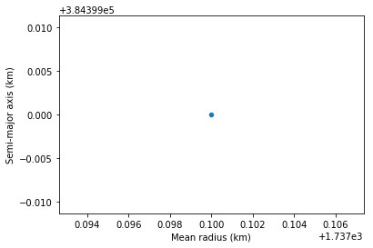

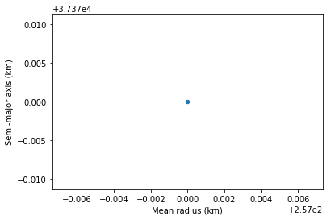

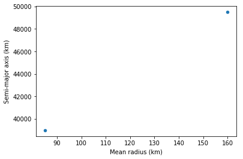

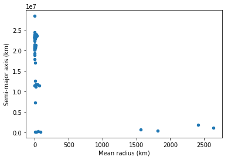

[figure not shown]

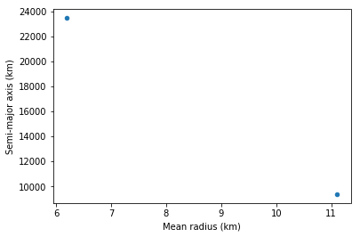

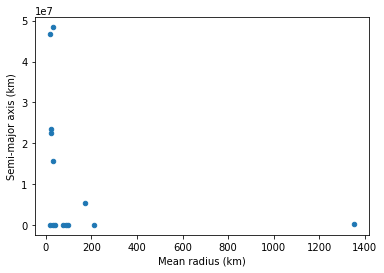

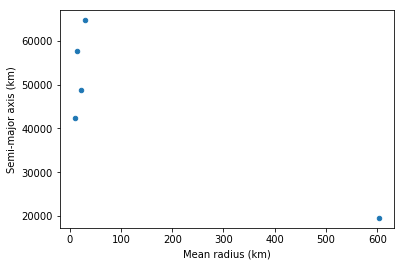

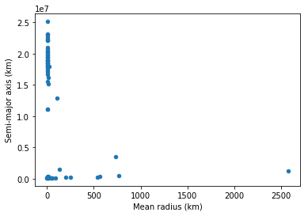

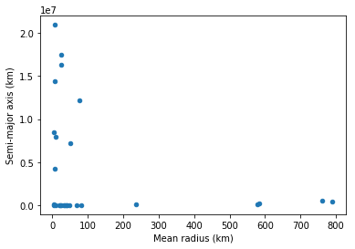

```python
# plot after groupby
solar_system.groupby('Planet').plot('Mean radius (km)', 'Semi-major axis (km)',kind='scatter')
```

It seems like there is no correlation between Mean radius (km) and Semi-major axis (km).

- Calculate correlaition rate

```python
solar_system['Mean radius (km)'].corr(solar_system['Semi-major axis (km)'])
```

```
-0.335363423947417
```